# Evaluation Function Illustration

Robert Schmidt - rschm

8/8/2020

# Overview and basic modeling

The following example illustrates the utility of the evaluation functions contained in `eval_functions.R`. I will employ the *Hitters* dataset from the `ISLR` library.

```r
source("eval_functions.R")
library(ISLR)

df = Hitters
str(df)
```

```
## 'data.frame':    322 obs. of  20 variables:
##  $ AtBat    : int  293 315 479 496 321 594 185 298 323 401 ...
##  $ Hits     : int  66 81 130 141 87 169 37 73 81 92 ...
##  $ HmRun    : int  1 7 18 20 10 4 1 0 6 17 ...
##  $ Runs     : int  30 24 66 65 39 74 23 24 26 49 ...
##  $ RBI      : int  29 38 72 78 42 51 8 24 32 66 ...
##  $ Walks    : int  14 39 76 37 30 35 21 7 8 65 ...
##  $ Years    : int  1 14 3 11 2 11 2 3 2 13 ...
##  $ CAtBat   : int  293 3449 1624 5628 396 4408 214 509 341 5206 ...
##  $ CHits    : int  66 835 457 1575 101 1133 42 108 86 1332 ...
##  $ CHmRun   : int  1 69 63 225 12 19 1 0 6 253 ...
##  $ CRuns    : int  30 321 224 828 48 501 30 41 32 784 ...
##  $ CRBI     : int  29 414 266 838 46 336 9 37 34 890 ...
##  $ CWalks   : int  14 375 263 354 33 194 24 12 8 866 ...
##  $ League   : Factor w/ 2 levels "A","N": 1 2 1 2 2 1 2 1 2 1 ...
##  $ Division : Factor w/ 2 levels "E","W": 1 2 2 1 1 2 1 2 2 1 ...
##  $ PutOuts  : int  446 632 880 200 805 282 76 121 143 0 ...
##  $ Assists  : int  33 43 82 11 40 421 127 283 290 0 ...
##  $ Errors   : int  20 10 14 3 4 25 7 9 19 0 ...
##  $ Salary   : num  NA 475 480 500 91.5 750 70 100 75 1100 ...
##  $ NewLeague: Factor w/ 2 levels "A","N": 1 2 1 2 2 1 1 1 2 1 ...
```

```r
N = nrow(df); p = ncol(df) - 1
print(paste0("There are ", N, " rows and ", p, " predictors in the Hitters dataset."))
```

```
## [1] "There are 322 rows and 19 predictors in the Hitters dataset."
```

## Correlation, VIF, and significance

We see that the *Hitters* dataset has a variety of predictor types, including a few factor variables. Let us employ the `find_corr` function to see which predictors are the most highly correlated, accounting for the different predictor types.

```r
find_corr(df, method.input = "hetcor") %>% head()
```

|  | predictor_1 | predictor_2 | correlation |
| --- | --- | --- | --- |
| 168 | CAtBat | CHits | 0.9950528 |
| 394 | League | NewLeague | 0.9930396 |
| 209 | CHits | CRuns | 0.9845438 |
| 208 | CAtBat | CRuns | 0.9827469 |
| 21 | AtBat | Hits | 0.9639432 |
| 228 | CAtBat | CRBI | 0.9507314 |

It is evident that a number of the predictors are highly collinear.

Dodging this issue for now, I will run a basic regression of Salary against all predictors in the data frame.

```r
lm.fit = lm(Salary ~ ., data = df)
```

What are the most significant predictors at a 0.05 cutoff?

```r
find_sig_vars(lm.fit, sig.cutoff = 0.05) %>% arrange(p_val)
```

| var_names | coef | sd | z | p_val |
| --- | --- | --- | --- | --- |
| PutOuts | 0.2818925 | 0.0774406 | 3.640114 | 0.0003329 |
| Walks | 6.2312863 | 1.8285038 | 3.407861 | 0.0007662 |
| Hits | 7.5007675 | 2.3775341 | 3.154852 | 0.0018082 |
| AtBat | -1.9798729 | 0.6339780 | -3.122936 | 0.0020077 |
| DivisionW | -116.8492456 | 40.3669516 | -2.894676 | 0.0041408 |
| CWalks | -0.8115709 | 0.3280825 | -2.473679 | 0.0140574 |

We see that a number of predictors are highly significant, although the significance is questionable given the degree of collinearity in the dataset. To address this, let’s check the VIF of this basic linear regression.

```r
find_VIF(lm.fit) %>% head()
```

|  | predictor | GVIF |
| --- | --- | --- |
| 1 | CHits | 502.95429 |
| 2 | CAtBat | 251.56116 |
| 3 | CRuns | 162.52081 |
| 4 | CRBI | 131.96586 |
| 5 | CHmRun | 46.48846 |
| 6 | Hits | 30.28126 |

These VIFs are explosively large! Anything above 10 is considered problematic, and these are in the hundreds.  
Again skirting the actual issue of model integrity, how do the predictions of a linear model fare against the actual values? Some of the salaries have missing values - since this exercise is just meant to illustrate the utility of the evaluation functions, I will remove these from the dataset.

## Model evaluation

```r
df.clean = df[!is.na(df$Salary), ]
N = nrow(df.clean)
data_split = sample(N, 0.7*N, replace = FALSE)
train = df.clean[data_split, ]
test = df.clean[-data_split, ]

lm.fit = lm(Salary ~ ., data = train)
preds = predict(lm.fit, test)
RMSE(preds, test$Salary)
```

```
## [1] 246.5847
```

We can also consider the distribution of the actual vs. predicted salaries:

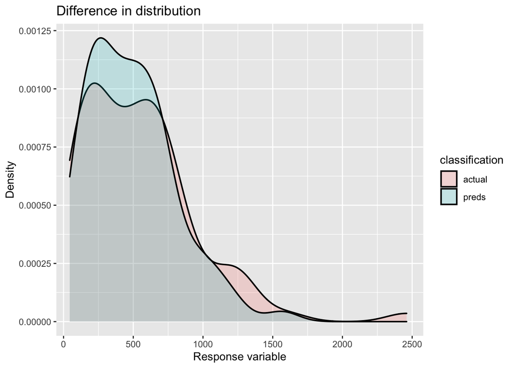

```r
dist_eval(preds, test$Salary)
```

How does the model fare at different quartiles of the actual salary?

```r
RMSE_ntile(preds, test$Salary, n_percentile = 4)
```

| ntile | test_RMSE |
| --- | --- |
| 1 | 179.3457 |
| 2 | 148.7045 |
| 3 | 191.1708 |
| 4 | 396.4999 |

We see that the RMSE is worst on the highest 25% of the data.

If we plot the empirical cdfs of the predicted and actual salary, what is the maximum difference between the distributions?

```r
ks_eval(preds, test$Salary)
```

```
## [1] "K-S test statistic: 0.11392"
```

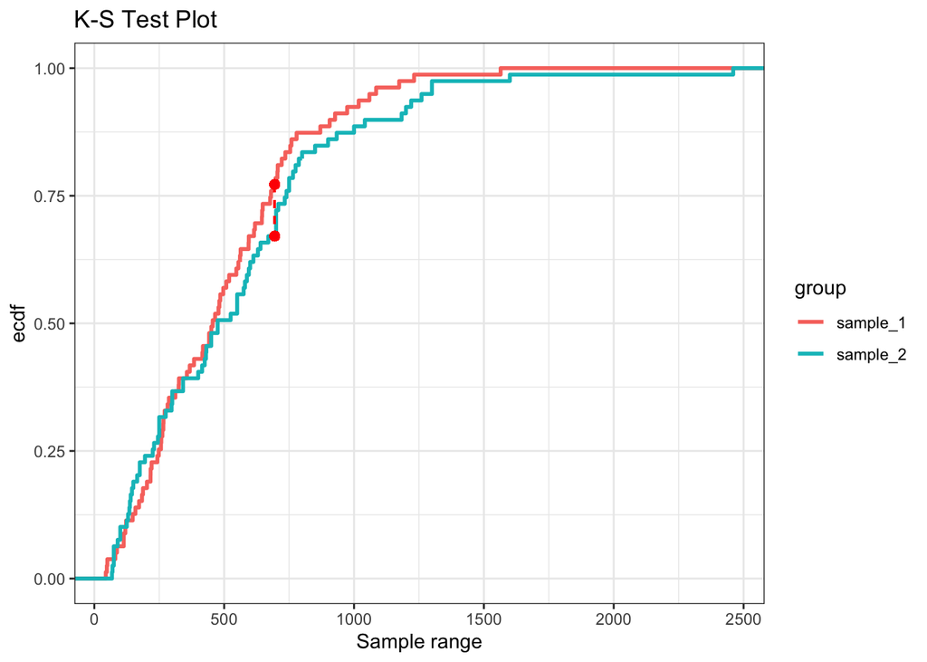